# 02806 Social Data Analysis and Visualization - Project B

Group 3: s252711, s252692, s252611

link to the webpage: https://zoelinnn.github.io/

## 1. Motivation

### 1.1 What is your dataset?

**Primary Dataset: DOB NOW Instead of BIS**

NYC's Department of Buildings stores construction job filings in two parallel databases:

> - BIS (DOB Job Application Filings, ic3t-wcy2): Legacy system, operating since 2000 (https://data.cityofnewyork.us/Housing-Development/DOB-Job-Application-Filings/ic3t-wcy2/about_data)
> - DOB NOW (Build Job Application Filings, w9ak-ipjd): New system, gradually rolled out since 2017 (https://data.cityofnewyork.us/Housing-Development/DOB-NOW-Build-Job-Application-Filings/w9ak-ipjd/about_data)

We chose DOB NOW as our primary dataset for three reasons:

> - Currency: BIS has been declining since 2018 and was largely retired after 2022; DOB NOW is the system currently in active use, providing data through 2025.
> - Data quality: DOB NOW has standardized field names, is fully electronic, and has low missingness (key fields such as latitude and bbl have less than 3% missing).
> - Temporal alignment with PLUTO: PLUTO is a 2025 snapshot, and the DOB NOW time window aligns naturally with it, avoiding the "current PLUTO state vs. historical BIS filings" causal mismatch.

We considered merging the two datasets to obtain a longer time series but ultimately decided against it. The two systems have incompatible primary keys (numeric Job vs. prefixed job_filing_number), inconsistent date semantics (BIS's Pre-Filing Date is the submission date while DOB NOW's current_status_date is the most recent status update), entirely different Job Type encodings (NB/A1/A2 vs. ALT-CO/ALT-GC), and overlapping projects in the 2016–2019 transition period. Forcibly merging them would introduce serious specification inconsistencies — too costly for a two-week project.

**Supplementary Dataset: PLUTO**

We introduced PLUTO (Primary Land Use Tax Lot Output, 64uk-42ks) as an auxiliary dataset providing lot-level attributes (year built, FAR, owner type, etc.). (https://data.cityofnewyork.us/City-Government/Primary-Land-Use-Tax-Lot-Output-PLUTO-/64uk-42ks/about_data)

The two datasets are linked through **BBL (Borough-Block-Lot, a 10-digit lot identifier)**, achieving a final match rate of 97.6%.

We retained only 11 PLUTO columns directly relevant to our analysis (yearbuilt, bldgclass, unitsres, unitstotal, numfloors, bldgarea, assesstot, builtfar, residfar, landmark, ownertype) to avoid column bloat.

### 1.2 Why did you choose this/these particular dataset(s)?

Together they form the minimal sufficient set for answering the question this project poses.

The value of permit filing data lies in its proximity to the moment of decision. Completed building data or property transaction records reflect outcomes that trail the original decision by years. Permit applications capture intention and action at the source, making them far more sensitive to shifts in market expectations and policy conditions. More importantly, they decompose the macro narrative of a construction surge into verifiable components, making the divergence between new buildings and alterations visible. If only total permit volume is examined, this structural change disappears entirely into the aggregate.

PLUTO is introduced to answer the second question: why does construction concentrate where it does rather than somewhere else. Permit data alone can describe where building is happening, but cannot explain why. Development potential, as a quantifiable variable, transforms the relationship between zoning capacity and market behavior into something testable rather than speculative.

Neither dataset is without limitation. PLUTO is a 2025 cross-sectional snapshot while the permit records span four years, meaning that a lot which received a filing in 2022 and completed construction by 2023 may show reduced remaining development potential in the 2025 snapshot precisely because that construction consumed floor area ratio. The analysis therefore describes spatial association rather than strict causality.

### 1.3 What was your goal for the end user's experience?

The project aims to dismantle a deeply held urban intuition. When most people think about construction in New York City, they picture the Manhattan skyline. The real surge is happening in Bushwick, Mott Haven, and Tottenville, names that carry none of the cultural weight of Midtown. Convincing readers to accept and genuinely internalize a conclusion that runs against their prior assumptions is the central narrative challenge this project had to solve.

The interactive maps and quarterly animation are designed so that readers discover the pattern themselves rather than being told it. People place more trust in conclusions they arrive at through active exploration than in those they receive passively. When a reader drags the timeline slider and watches Brooklyn and Staten Island deepen quarter by quarter while Manhattan remains pale throughout, the persuasive force of that visual experience cannot be replicated by a static chart.

The project ultimately aims to serve two audiences simultaneously. For urban planning practitioners and policy researchers, it offers a verifiable, lot-level spatial analysis framework. For ordinary New Yorkers, it offers a new lens through which to understand their own city: the neighborhoods genuinely reshaping New York's physical fabric over the coming decades are not the ones adjacent to Fifth Avenue, but the ones a few stops past the end of the L train.

## 2. Basic stats

### 2.1 Write about your choices in data cleaning and preprocessing.

#### 2.1.1 Time window selection

Our time window went through three iterations:

| **Stage** | **Window** | **Reason** |
| --- | --- | --- |
| Initial | 2010–2019 (BIS era) | Default 10-year window from intuition |
| Revision 1 | 2003–2015 (based on BIS distribution) | Discovered post-2016 data was actually a "system migration artifact" |
| Final | 2021–2025 (DOB NOW) | Recalibrated after switching to DOB NOW |

#### 2.1.2 Data clean and preprocess

**DOB NOW provides 5 date fields, handled as follows:**

> - filing_date: Primary time-axis variable for analysis (it marks the unambiguous start of the project lifecycle).
> - approved_date / first_permit_date / signoff_date: Used to derive process durations, but we do not drop rows based on their missingness — these missing values reflect the project's stage in the workflow (50% of projects haven't reached completion is normal), not data quality issues.
> - All dates were converted to pd.datetime, with invalid values (e.g., 0000-00-00) coerced to NaT.

**Geographic Fields:**

> - Coordinate filtering: lat ∈ [40.4, 41.0], lon ∈ [−74.3, −73.6] (NYC's reasonable bounds), removing out-of-range outliers.
> - Borough standardization: Uppercased and stripped of whitespace.
> - Retain NaN selectively: 6,403 records (0.7%) have a valid BBL but no coordinates. These were uniformly distributed across boroughs and years, suggesting random missingness. We exclude them from spatial analyses but keep them for non-spatial analyses.

**Job Type Simplification:** The original job_type field had numerous fine-grained values. We derived job_type_clean, simplified into 6 categories

> - NB ← New Building / ALT-CO with Existing Elements
> - ALT ← Alteration
> - ALT-CO ← Alteration CO
> - DM ← Full Demolition
> - NoWork ← No Work
> - Other ← Everything else

The simplification principle was to retain analytically meaningful core categories while preventing long-tail types from diluting the main analysis.

**Filing Status Simplification:** The original filing_status field contained 46 fine-grained values (e.g., On Hold – Pending Supersede of Owner, LL 158-2017-Denied, Plan Examiner Review), which was too fragmented for analysis. We derived filing_status_clean, semantically grouped into 6 categories:

> - Completed ← LOC Issued / CO Issued / Signed-off
> - Approved/Permitted ← Approved / Permit Entire / Permit Issued
> - In Review ← Plan Examiner Review / Pending / Awaiting / Incomplete
> - On Hold ← Various On Hold states
> - Terminated ← Withdrawn / Revoked / Denied / Intent to Revoke
> - Objections/Issues ← Objections / QA Failed The grouping criterion was semantic meaning, not frequency — for example, all "On Hold" states were merged into one category regardless of the specific reason for the hold.

**PLUTO's Missingness:** Two PLUTO fields had unusually high missingness (>65%), but this is by-design semantics rather than a data quality issue:

| **Field** | **Missing Rate** | **True Meaning** |
| --- | --- | --- |
| landmark_pluto | 77.3% | PLUTO populates this only for landmarked buildings; missing means "not landmarked" |
| ownertype_pluto | 68.4% | Populated only for non-private owners (City/Mixed/Tax-exempt); missing means "Private" |

We addressed these with two derived fields:

> - is_landmark: Boolean, equivalent to landmark_pluto.notna().
> - ownertype_clean: Filled missing values with 'P' (Private) to make the field semantically complete.

### 2.2 Write a short section that discusses the dataset stats, containing key points/plots from your exploratory data analysis.

#### 2.2.2 Key Distributions

**Job Type Composition:** The vast majority of filings are alterations to existing buildings, with new construction making up a small but rapidly growing share.

[output not shown]

[output not shown]

**Project Status:** Filings reflect different stages of the DOB workflow at the time of data extraction.

[output not shown]

#### 2.2.3 Temporal Trends

> - Total filings are stable: Across 2021–2025, the total number of monthly filings hovers around 11,000–13,000, growing only modestly overall.
> - But composition is shifting dramatically: When broken out by Job Type, the picture changes:
> > - ALT (the dominant category) grew only 5% from 2021 H2 to 2025
> > - ALT-CO grew +253%
> > - NB grew +258% — the largest absolute increase, from ~410 filings/month in 2021 H2 to ~1,470 filings/month in 2025

This dichotomy — stable total volume masking a structural shift toward new construction — frames the central question of our analysis.

## 3. Data Analysis

### 3.1 Total number of applications

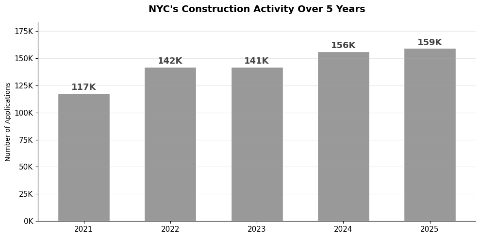

```python
import matplotlib.pyplot as plt
import numpy as np
import pandas as pd

df = pd.read_csv("F:/DTU/02806 Social Data Analysis and Visualization/ProjectB/data/merged_data_0428.csv")
yearly_total = (df.groupby('filing_year').size())

fig, ax = plt.subplots(figsize=(10, 5))

bars = ax.bar(yearly_total.index.astype(str), yearly_total.values,
              color='#999999', edgecolor='white', width=0.6)


for bar, val in zip(bars, yearly_total.values):
    ax.text(bar.get_x() + bar.get_width()/2, val + 3000,
            f'{int(val/1000)}K', ha='center',
            fontsize=13, fontweight='bold', color='#444')

ax.set_title("NYC's Construction Activity Over 5 Years",
             fontsize=14, fontweight='bold', pad=15)
ax.set_ylabel('Number of Applications')
ax.set_xlabel('')
ax.yaxis.set_major_formatter(plt.FuncFormatter(lambda x, _: f'{int(x/1000)}K'))
ax.set_ylim(0, yearly_total.max() * 1.15)


ax.spines['top'].set_visible(False)
ax.spines['right'].set_visible(False)
ax.grid(axis='y', alpha=0.3)
ax.tick_params(axis='both', labelsize=11)

plt.tight_layout()
plt.show()
```

```python
df1 = pd.read_csv("F:/DTU/02806 Social Data Analysis and Visualization/ProjectB/raw data/DOB_Job_Application_Filings.csv")
df2 = pd.read_csv("F:/DTU/02806 Social Data Analysis and Visualization/ProjectB/raw data/DOB_NOW__Build___Job_Application_Filings.csv")

df1 = df1[df1['Job Type'] == 'NB']
df2 = df2[df2['Job Type'] == 'New Building']

df1 = df1.copy()
df2 = df2.copy()
df1['Pre- Filing Date'] = pd.to_datetime(df1['Pre- Filing Date'], errors='coerce')
df2['Filing Date'] = pd.to_datetime(df2['Filing Date'], errors='coerce')

df1['year'] = df1['Pre- Filing Date'].dt.year
df2['year'] = df2['Filing Date'].dt.year

counts1 = df1['year'].value_counts()
counts2 = df2['year'].value_counts()

years = list(range(2015, 2027))
values = [int(counts1.get(y, 0) + counts2.get(y, 0)) for y in years]


years = list(range(2015, 2027))
values = [int(counts1.get(y, 0) + counts2.get(y, 0)) for y in years]
```

[figure not shown]

```python
fig, ax = plt.subplots(figsize=(11, 5))
colors = ['#999'] * 5 + ['#d62728'] + ['#ff9896'] + ['#2ca02c'] * 4 + ['#1f77b4']


bars = ax.bar(years, values, color=colors, edgecolor='white')
for bar, v in zip(bars, values):
    ax.text(bar.get_x() + bar.get_width()/2, v + 200, f'{v:,}',
            ha='center', fontsize=9)


ax.axvspan(2019.5, 2020.5, alpha=0.1, color='gray')
ax.text(2020, 12000, 'COVID', ha='center', fontsize=10, style='italic')

ax.axhline(4395, color='#1f77b4', linestyle='--', linewidth=1, alpha=0.7)
# ax.text(2025, 4900, '2019 baseline (4,395)', ha='right', fontsize=9, color='#666', style='italic')
ax.text(2025, 4395, '2019 baseline (4,395)',
        ha='right', va='bottom',
        fontsize=10, color='#1f77b4',
        bbox=dict(facecolor='white', alpha=0.7, edgecolor='none'))

ax.axhline(8567, color='#d62728', linestyle=':', linewidth=1, alpha=0.5)
# ax.text(2025, 9000, '2015 peak (8,567)', ha='right', fontsize=9, color='#999', style='italic')
ax.text(2025, 8567, '2015 peak (8,567)',
        ha='right', va='bottom',
        fontsize=10, color='#d62728',
        bbox=dict(facecolor='white', alpha=0.7, edgecolor='none'))


ax.set_xlabel('Year')
ax.set_ylabel('NB Applications')
ax.set_title('NYC New Building Applications: A Decade in Context (2015-2025)\n'
             'The 2021-2025 surge surpasses both the 2019 baseline (+204%) and 2015 peak (+56%)',
             fontsize=12, fontweight='bold')
ax.set_xticks(years)
plt.tight_layout()
plt.show()
```

The figure above shows the annual trend in NB (New Building) applications. For comparison, we have highlighted 2020 (the COVID period) and marked the 2019 baseline and the 2015 peak. It can be seen that new construction activity in NYC has been declining throughout the latter half of the 2010s. Then, by 2025—13,340 applications. This represents a 204% increase compared to pre-pandemic levels and is 56% higher than the 2015 peak. This is not merely a post-pandemic rebound. It is a genuine recovery in new construction that has surpassed historical levels.

### 3.2 Monthly trend by job type

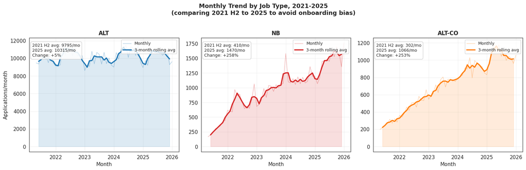

```python
types_to_plot = ['ALT', 'NB', 'ALT-CO']

monthly = (df.groupby([pd.Grouper(key='filing_date', freq='ME'),
                       'job_type_clean'])
             .size()
             .unstack(fill_value=0))
monthly_smooth = monthly.rolling(window=3, center=True).mean()

fig, axes = plt.subplots(1, 3, figsize=(16, 5), sharex=True)

for ax, jt in zip(axes, types_to_plot):
    ax.plot(monthly.index, monthly[jt], color=COLOR_PALETTE.get(jt, '#999'),
            alpha=0.35, linewidth=1, label='Monthly')
    ax.plot(monthly_smooth.index, monthly_smooth[jt],
            color=COLOR_PALETTE.get(jt, '#999'),
            linewidth=2.5, label='3-month rolling avg')
    ax.fill_between(monthly_smooth.index, 0, monthly_smooth[jt],
                    color=COLOR_PALETTE.get(jt, '#999'), alpha=0.15)

    avg_start = monthly[jt].loc['2021-07':'2021-12'].mean()
    avg_end = monthly[jt].loc['2025-01':'2025-12'].mean()
    change = (avg_end / avg_start - 1) * 100 if avg_start > 0 else 0

    ax.text(0.02, 0.95,
            f'2021 H2 avg: {avg_start:.0f}/mo\n'
            f'2025 avg: {avg_end:.0f}/mo\n'
            f'Change: +{change:.0f}%',
            transform=ax.transAxes, fontsize=9, va='top',
            bbox=dict(boxstyle='round,pad=0.4',
                      facecolor='white', edgecolor='#ccc', alpha=0.9))

    ax.set_title(jt, fontsize=12, fontweight='bold')
    ax.set_ylabel('Applications/month' if jt == 'ALT' else '')
    ax.set_xlabel('Month')
    ax.legend(loc='upper right', fontsize=9)
    ax.grid(True, alpha=0.3)

fig.suptitle('Monthly Trend by Job Type, 2021-2025\n'
             '(comparing 2021 H2 to 2025 to avoid onboarding bias)',
             fontsize=13, fontweight='bold', y=1.02)
plt.tight_layout()
plt.show()
```

Left (Alteration, ALT): Stable. Growth of just 5% over five years. There has been no increase in the workload for refurbishment workers.

Right (Alteration CO, ALT-CO): Rise. Applications to convert office buildings into residential properties and to repurpose retail spaces have increased by 253%.

Middle (New Building, NB): Rise. From 410 applications per month in the second half of 2021, the figure has surged to nearly 1,500 per month in 2025 – a 3.5-fold increase.

### 3.3 NB application in different borough

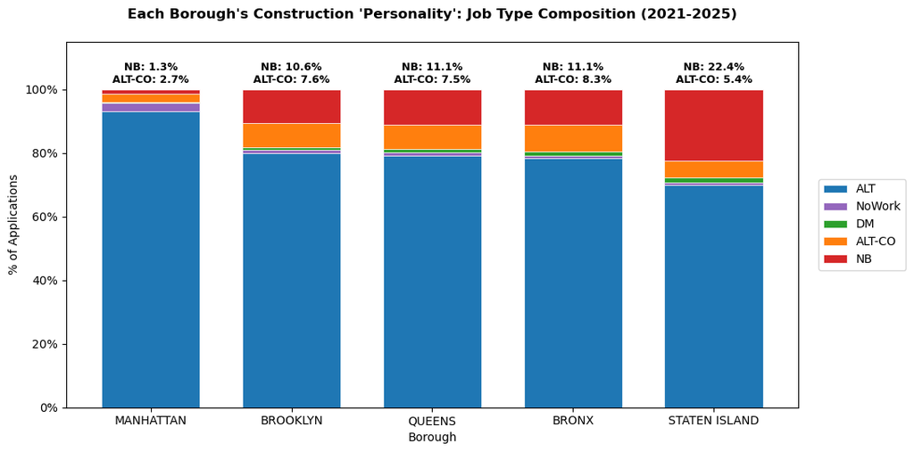

```
The percentage of NB and ALT-CO through Borough:
job_type_clean     NB  ALT-CO
borough
MANHATTAN        1.33    2.75
BROOKLYN        10.59    7.62
QUEENS          11.11    7.53
BRONX           11.14    8.29
STATEN ISLAND   22.36    5.38
```

```python
borough_jobtype = (df.groupby(['borough', 'job_type_clean'])
                     .size()
                     .unstack(fill_value=0))

borough_pct = borough_jobtype.div(borough_jobtype.sum(axis=1), axis=0) * 100

borough_pct = borough_pct.sort_values('ALT', ascending=False)

type_order = ['ALT', 'NoWork', 'DM', 'ALT-CO', 'NB']
type_order = [t for t in type_order if t in borough_pct.columns]
borough_pct = borough_pct[type_order]

fig, ax = plt.subplots(figsize=(11, 5.5))
borough_pct.plot(kind='bar', stacked=True, ax=ax,
                 color=[COLOR_PALETTE.get(c, '#999') for c in type_order],
                 edgecolor='white', linewidth=0.5, width=0.7)

for i, borough in enumerate(borough_pct.index):
    nb = borough_pct.loc[borough, 'NB'] if 'NB' in borough_pct.columns else 0
    altco = borough_pct.loc[borough, 'ALT-CO'] if 'ALT-CO' in borough_pct.columns else 0
    ax.text(i, 102, f'NB: {nb:.1f}%\nALT-CO: {altco:.1f}%',
            ha='center', fontsize=9, fontweight='bold')

ax.set_xlabel('Borough')
ax.set_ylabel('% of Applications')
ax.set_title("Each Borough's Construction 'Personality': Job Type Composition (2021-2025)",
             fontsize=12, fontweight='bold', pad=20)
ax.legend(loc='center left', bbox_to_anchor=(1.02, 0.5))
ax.set_xticklabels(borough_pct.index, rotation=0)
ax.set_ylim(0, 115)
ax.yaxis.set_major_formatter(plt.FuncFormatter(lambda x, _: f'{int(x)}%' if x <= 100 else ''))

plt.tight_layout()
plt.show()

print("The percentage of NB and ALT-CO through Borough:")
print(borough_pct[['NB', 'ALT-CO']].round(2).to_string())
```

Brooklyn / Queens / Bronx (the three in the middle): They look almost identical. Each borough consists of ~80% refurbishment + ~10% new builds – constituting the ‘outer four boroughs pattern’ of NYC.

```
               2021 H2 (annualized)  2025    Growth %
borough
BRONX                           470  2820  500.000000
BROOKLYN                       1732  6502  275.404157
QUEENS                         1444  5168  257.894737
MANHATTAN                       448  1223  172.991071
STATEN ISLAND                   832  1925  131.370192
```

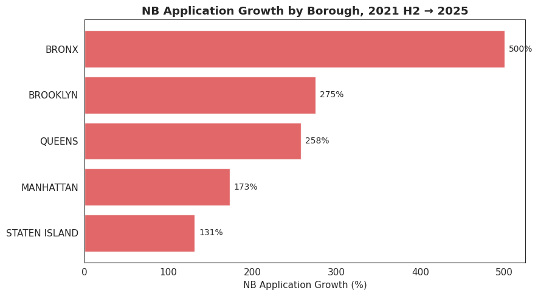

```python
nb_by_borough_year = (df[df['job_type_clean'] == 'NB']
                        .groupby(['filing_year', 'borough'])
                        .size()
                        .unstack(fill_value=0))

nb_h2_2021 = (df[(df['job_type_clean'] == 'NB') &
                  (df['filing_date'] >= '2021-07-01') &
                  (df['filing_date'] < '2022-01-01')]
                .groupby('borough').size())
nb_2025 = (df[(df['job_type_clean'] == 'NB') &
               (df['filing_date'] >= '2025-01-01') &
               (df['filing_date'] < '2026-01-01')]
             .groupby('borough').size())

growth = pd.DataFrame({
    '2021 H2 (annualized)': nb_h2_2021 * 2,
    '2025': nb_2025
})
growth['Growth %'] = (growth['2025'] / growth['2021 H2 (annualized)'] - 1) * 100
print(growth.sort_values('Growth %', ascending=False))


fig, ax = plt.subplots(figsize=(9, 5))
growth_sorted = growth.sort_values('Growth %', ascending=True)
ax.barh(growth_sorted.index, growth_sorted['Growth %'],
        color='#d62728', alpha=0.7)
for i, (idx, row) in enumerate(growth_sorted.iterrows()):
    ax.text(row['Growth %'] + 5, i, f'{row["Growth %"]:.0f}%',
            va='center', fontsize=10)
ax.set_xlabel('NB Application Growth (%)')
ax.set_title('NB Application Growth by Borough, 2021 H2 → 2025',
             fontweight='bold')
plt.tight_layout()
plt.show()
```

The growth in NB applications has been most pronounced in the Bronx, reaching 500%.

### 3.4 Filing status

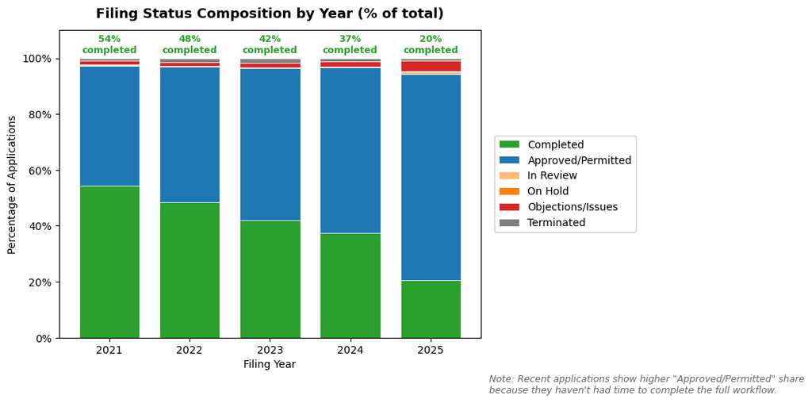

```
filing_status_clean  Approved/Permitted  Completed  In Review  Objections/Issues  On Hold  Terminated
filing_year
2021                              50703      63835        143               1534      283        1189
2022                              68731      68792        167               2062      379        1903
2023                              77262      59503        135               2196      417        2405
2024                              92287      58405        208               2764      462        1944
2025                             117451      32529       1231               6285      321        1344
```

```python
status_year = (df.groupby(['filing_year', 'filing_status_clean'])
                 .size()
                 .unstack(fill_value=0))
status_pct = status_year.div(status_year.sum(axis=1), axis=0) * 100

status_order = ['Completed', 'Approved/Permitted', 'In Review',
                'On Hold', 'Objections/Issues', 'Terminated', 'Other']
status_order = [s for s in status_order if s in status_pct.columns]
status_pct = status_pct[status_order]

status_colors = {
    'Completed': '#2ca02c', 'Approved/Permitted': '#1f77b4',
    'In Review': '#ffbb78', 'On Hold': '#ff7f0e',
    'Objections/Issues': '#d62728', 'Terminated': '#7f7f7f',
    'Other': '#cccccc'
}

fig, ax = plt.subplots(figsize=(11, 5.5))
status_pct.plot(kind='bar', stacked=True, ax=ax,
                color=[status_colors.get(s, '#999') for s in status_pct.columns],
                edgecolor='white', linewidth=0.5, width=0.75)

ax.set_xlabel('Filing Year')
ax.set_ylabel('Percentage of Applications')
ax.set_title('Filing Status Composition by Year (% of total)',
             fontsize=13, fontweight='bold', pad=12)
ax.legend(loc='center left', bbox_to_anchor=(1.02, 0.5), framealpha=0.95)
ax.set_xticklabels(status_pct.index.astype(int), rotation=0)
ax.yaxis.set_major_formatter(plt.FuncFormatter(lambda x, _: f'{int(x)}%'))
ax.set_ylim(0, 100)


ax.text(1.02, -0.12,
        'Note: Recent applications show higher "Approved/Permitted" share\n'
        'because they haven\'t had time to complete the full workflow.',
        transform=ax.transAxes, fontsize=9, style='italic', color='#666',
        verticalalignment='top')
for i, (year, row) in enumerate(status_pct.iterrows()):
    completed_pct = row.get('Completed', 0)
    ax.text(i, 102, f'{completed_pct:.0f}%\ncompleted',
            ha='center', fontsize=9, color='#2ca02c', fontweight='bold')

ax.set_ylim(0, 110)
plt.tight_layout()
plt.show()

print(status_year.to_string())
```

The most prominent trend is the clear relationship between the age of the filing and its completion rate. "Completed" applications steadily decrease from 54% in 2021 down to 20% in 2025. At the same time, the "Approved/Permitted" share expands significantly in more recent years. This creates an inverse relationship between the two main categories.

## 4. Genre

### Which tools did you use from each of the 3 categories of Visual Narrative (Figure 7 in Segal and Heer). Why?

For Visual Structuring, we used Establishing Shot / Splash Screen, Consistent Visual Platform, and Progress Bar / Timebar. The opening of the website works like an establishing shot. It quickly tells readers what the project is about. After that, the website keeps a consistent layout, with repeated maps, charts, figure captions, and section titles. This makes the story easier to follow. The time-based figures also help readers see how the pattern changes from 2021 to 2025.

For Highlighting, we used Feature Distinction, Close-Ups, and Motion. We used color to separate job types and borough modes, and we used point size to show where NB activity is stronger. We also labeled important neighborhoods and used rankings to draw attention to the places driving the surge. The animated time views help show how NB activity changes over time.

For Transition Guidance, we used Object Continuity and Animated Transitions. The same ideas appear throughout the website: NB filings, borough modes, NTAs, and development potential. This helps readers connect one section to the next. The story first shows the citywide growth, then moves to boroughs and neighborhoods, and finally tests land development potential. The animations and repeated visual elements help the transitions feel natural.

### Which tools did you use from each of the 3 categories of Narrative Structure (Figure 7 in Segal and Heer). Why?

For Ordering, we used Linear ordering. First, we show that the NB surge is real. Then we show where it happened. Finally, we ask whether land development potential helps explain the pattern. This order works well because readers need to understand the basic trend before they can understand the spatial explanation.

For Interactivity, we used Hover Highlighting / Details, Filtering / Selection / Search, and Very Limited Interactivity. The website lets readers hover over charts and maps to see more details about boroughs, NTAs, and neighborhoods. Some views also let readers compare patterns across time or categories. But we kept the interaction limited on purpose. We wanted the website to remain a guided story, not a complicated dashboard.

For Messaging, we used Captions / Headlines, Annotations, Introductory Text, and Summary / Synthesis. Each section has a clear title and a short explanation of what the reader should notice. The captions help explain the main takeaway from each figure. We also use careful language in the final section for summary.

## 5. Visualizations

### 5.1 Story 1: NYC is growing

#### Explain the visualizations you've chosen

In Story 1, we use the four figures from Section 3 (Data Analysis). They are all statistical analysis figures, progressing from a broad overview to borough-level patterns.

#### Why are they right for the story you want to tell?

##### 1. Five-Year Application Total Overview

**What it shows**: A simple gray bar chart of total annual filings in NYC, 2021–2025.

**Why it works**: This figure does the unglamorous but essential work of *setting up the puzzle*. It tells the reader that NYC's overall construction activity has been remarkably stable. Non-technical readers expect "construction is growing" to mean "more total filings" — the flat-ish gray bars subtly contradict that expectation, creating narrative tension: *if total construction isn't really increasing, then what is the story?*

##### 2. Three-Type Faceted Trend (NB / ALT / ALT-CO)

**What it shows**: Monthly filing trends for the three major Job Types, each with its own y-axis scale and clearly labeled growth rate (ALT: +5%, ALT-CO: +253%, NB: +258%).

**Why it works**:

- **Faceting over stacking**: A stacked area chart would visually crush NB and ALT-CO under the dominant ALT. Separate panels with independent y-axes give the small-but-rapidly-growing categories equal visual weight.
- **Smoothed trend lines**: Raw monthly data alone looks noisy; smoothed-only would lose authenticity. The combination preserves both signal and texture.
- **Embedded growth labels**: Putting "+258%" directly on the NB panel turns the figure into a self-contained finding — a reader who only glances at it already knows the headline.
- **Distinguishes NB from ALT-CO**: Despite similar growth rates, NB's higher absolute baseline (~410/month vs. ~302/month) and greater absolute change hint that it is the more substantial phenomenon — motivating our later focus on NB specifically.

##### 3. 11-Year Long-Term Trend (2015–2025)

**What it shows**: A bar chart of NB filings per year from 2015 to 2025, combining BIS (legacy) and DOB NOW (current) data, with reference lines for the 2019 baseline and 2015 peak.

**Why it works**: By extending the timeline back to 2015, it reveals three findings at once:

1. NB activity was already declining through the late 2010s (8,567 in 2015 → 4,395 in 2019), well before the pandemic.
2. The 2020 pandemic trough (2,938) was modest, not catastrophic — a rebound argument can explain at most a ~50% recovery.
3. 2025's level (13,340) exceeds the 2019 baseline by 204% *and* the 2015 peak by 56% — NYC has reached an NB level with no precedent in the past decade.

##### 4. Borough Composition

**What it shows**: A 100%-stacked bar chart, one bar per borough, showing the percentage breakdown of Job Types per borough, with NB and ALT-CO percentages annotated above each bar.

**Why it works**: This figure acts as the *bridge to Story 2*. Having established that NB growth is real and unprecedented, the natural next question is *"Where is this happening?"* The figure surfaces a counterintuitive finding: the five boroughs behave like three different cities. This reframing establishes the conceptual scaffolding for Story 2 — spatial heterogeneity is about *what kind* of construction each area does, not just *how much*.

### 5.2 Story 2: The places where NYC is really growing

#### Explain the visualizations you've chosen.

In story 2, we use Plotly with geodata and one bar chart.

#### Why are they right for the story you want to tell?

```python
import plotly.express as px
import plotly.graph_objects as go
from plotly.subplots import make_subplots


nta_summary = (df.dropna(subset=['nta'])
                .groupby('nta')
                .agg(borough=('borough', 'first'),
                     total=('job_filing_number', 'count'),
                     nb_count=('job_type_clean', lambda x: (x == 'NB').sum()))
                .reset_index())
nta_summary['nb_pct'] = nta_summary['nb_count'] / nta_summary['total'] * 100

def borough_mode(b):
    if b == 'MANHATTAN':
        return 'Manhattan (Built-out)'
    elif b == 'STATEN ISLAND':
        return 'Staten Island (Suburban)'
    else:
        return 'Outer Four (Brooklyn/Queens/Bronx)'

nta_summary['borough_mode'] = nta_summary['borough'].apply(borough_mode)


fig = make_subplots(
    rows=1, cols=3,
    subplot_titles=('Manhattan<br>(Built-out)',
                    'Outer Four<br>(Brooklyn/Queens/Bronx)',
                    'Staten Island<br>(Suburban)'),
    specs=[[{'type': 'choroplethmapbox'}] * 3],
    horizontal_spacing=0.01,
)

modes = ['Manhattan (Built-out)',
         'Outer Four (Brooklyn/Queens/Bronx)',
         'Staten Island (Suburban)']


nb_pct_max = nta_summary['nb_pct'].quantile(0.95)

for i, mode in enumerate(modes):
    sub = nta_summary[nta_summary['borough_mode'] == mode]
    fig.add_trace(go.Choroplethmapbox(
        geojson=nta_geojson,
        locations=sub['nta'],
        featureidkey='properties.ntaname',
        z=sub['nb_count'],
        colorscale='Reds',
        zmin=0, zmax=nta_summary['nb_count'].quantile(0.95),
        marker_opacity=0.8,
        marker_line_width=0.3,
        showscale=(i == 2),
        colorbar=dict(title='NB Apps', x=1.02, len=0.85),
        hovertemplate='<b>%{location}</b><br>'
                      'NB applications: {customdata[0]}<br>'
                      'Total apps: {customdata[1]}<br>'
                      'NB share: {z:.1f}%<extra></extra>',
        customdata=sub[['nb_count', 'total']].values,
    ), row=1, col=i+1)


common_mapbox = dict(style='carto-positron', zoom=8.7,
                     center={'lat': 40.71, 'lon': -73.95})
fig.update_layout(
    mapbox=common_mapbox, mapbox2=common_mapbox, mapbox3=common_mapbox,
    title_text='NB Applications by NTA, Grouped by Borough Mode<br>'
               '<sub></sub>',
    height=550,
    margin={'r': 80, 't': 80, 'l': 0, 'b': 0},
)

fig.write_html(FIG_DIR / '02_nb_pct_by_mode.html')
fig.show()


print("\n=== NB through Borough pattern ===")
for mode in modes:
    sub = nta_summary[nta_summary['borough_mode'] == mode]
    n_high = (sub['nb_pct'] > 10).sum()
    print(f"\n{mode}:")
    print(f"  Total number of NTA : {len(sub)}")
    print(f"  NTA of NB > 10% : {n_high}")
    print(f"  NB application: {sub['nb_count'].sum():,}")
    print(f"  Top 3 NB app NTA:")
    print(sub.nlargest(3, 'nb_pct')[['nta', 'nb_count', 'total', 'nb_pct']].to_string(index=False))
```

[output not shown]

```
=== NB through Borough pattern ===

Manhattan (Built-out):
  Total number of NTA : 38
  NTA of NB > 10% : 2
  NB application: 3,606
  Top 3 NB app NTA:
                                                     nta  nb_count  total    nb_pct
The Battery-Governors Island-Ellis Island-Liberty Island        34    224 15.178571
                                 Kingsbridge-Marble Hill       175   1327 13.187641
                                        Randall's Island        15    173  8.670520

Outer Four (Brooklyn/Queens/Bronx):
  Total number of NTA : 188
  NTA of NB > 10% : 79
  NB application: 42,795
  Top 3 NB app NTA:
                    nta  nb_count  total    nb_pct
The Evergreens Cemetery         9     10 90.000000
        Pelham Bay Park        51    117 43.589744
         Soundview Park        12     29 41.379310

Staten Island (Suburban):
  Total number of NTA : 20
  NTA of NB > 10% : 17
  NB application: 7,484
  Top 3 NB app NTA:
                                   nta  nb_count  total    nb_pct
Annadale-Huguenot-Prince's Bay-Woodrow      1185   3454 34.308049
               Arden Heights-Rossville       441   1286 34.292379
                Tottenville-Charleston       671   2290 29.301310
```

> - **'NB Application Density by NTA'** is a choropleth map coloring NYC's ~200 NTAs by their total NB filing count. After Story 1 left readers asking "where," the very first map provides a clear visual reply: NB is concentrated in outer-borough corridors (Brooklyn's Bushwick-Williamsburg belt, Bronx's Mott Haven, Staten Island's southern tip), with Manhattan almost entirely pale. The reader sees, at a glance, that NB activity is geographically uneven — and that the heat is not in the place they likely expected.

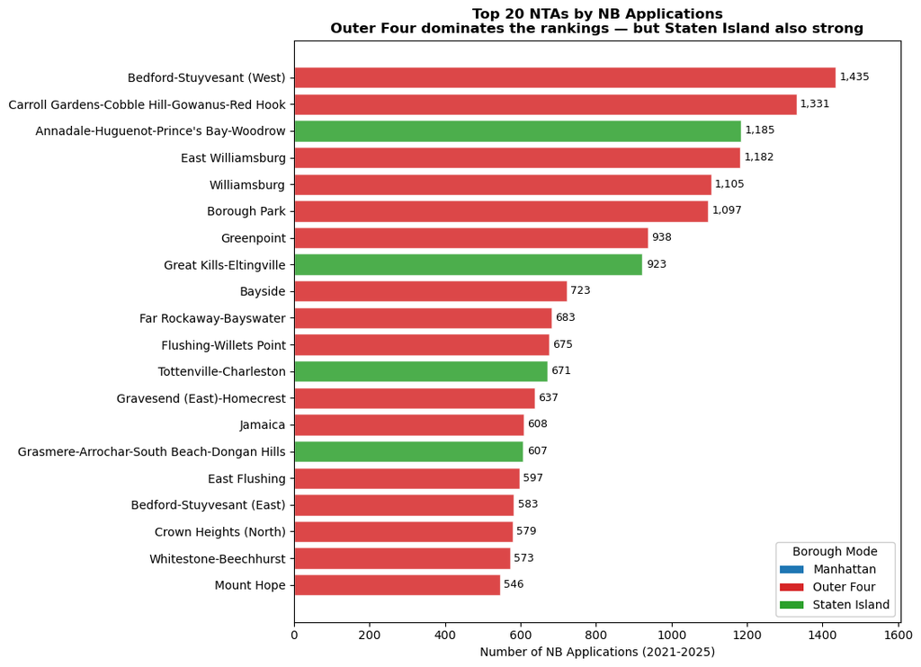

```
=== Top 20 NTA proportion of all NB applications ===
The top 20 NTAs account for 31.0% of all NB

=== Top 20 in ===
Outer Four       16
Staten Island     4
Name: mode, dtype: int64
```

```python
nta_nb = (df[df['job_type_clean'] == 'NB']
            .dropna(subset=['nta'])
            .groupby('nta')
            .agg(nb_count=('job_filing_number', 'count'),
                 borough=('borough', 'first'))
            .reset_index())

def borough_mode(b):
    if b == 'MANHATTAN':
        return 'Manhattan'
    elif b == 'STATEN ISLAND':
        return 'Staten Island'
    else:
        return 'Outer Four'

nta_nb['mode'] = nta_nb['borough'].apply(borough_mode)

# Top 20
top20 = nta_nb.nlargest(20, 'nb_count').sort_values('nb_count')

mode_colors = {
    'Manhattan': '#1f77b4',
    'Outer Four': '#d62728',
    'Staten Island': '#2ca02c',
}

fig, ax = plt.subplots(figsize=(11, 8))
bars = ax.barh(top20['nta'], top20['nb_count'],
               color=[mode_colors[m] for m in top20['mode']],
               alpha=0.85, edgecolor='white')

for bar, val in zip(bars, top20['nb_count']):
    ax.text(val + 10, bar.get_y() + bar.get_height()/2,
            f'{int(val):,}', va='center', fontsize=9)

from matplotlib.patches import Patch
legend_elems = [Patch(facecolor=c, label=m) for m, c in mode_colors.items()]
ax.legend(handles=legend_elems, loc='lower right',
          title='Borough Mode', framealpha=0.95)

ax.set_xlabel('Number of NB Applications (2021-2025)')
ax.set_title('Top 20 NTAs by NB Applications\n'
             'Outer Four dominates the rankings — but Staten Island also strong',
             fontsize=12, fontweight='bold')
ax.set_xlim(0, top20['nb_count'].max() * 1.12)

plt.tight_layout()
plt.show()

print(f"\n=== Top 20 NTA proportion of all NB applications ===")
total_nb = nta_nb['nb_count'].sum()
top20_nb = top20['nb_count'].sum()
print(f"The top 20 NTAs account for {top20_nb/total_nb*100:.1f}% of all NB")

print(f"\n=== Top 20 in ===")
print(top20['mode'].value_counts())
```

> - **'Top 20 NTAs Bar Chart'** is a horizontal bar chart of the 20 NTAs with the most NB filings, color-coded by Borough mode. The former figure establishes that "outer boroughs are hot," but a non-technical reader can't easily read NTA names off a colored map. This figure makes the heat legible — Bedford-Stuyvesant West, Williamsburg, Annandale-Tottenville suddenly become specific places the reader can recognize. Two findings stand out: not a single Manhattan NTA appears in the top 20, and Staten Island contributes four — disproportionate to its share of total filings. This concreteness is essential for a public-facing report.

```python
import plotly.express as px


nb_df = df[df['job_type_clean'] == 'NB'].copy()
nb_df['filing_quarter'] = nb_df['filing_date'].dt.to_period('Q').astype(str)


nb_df = nb_df[nb_df['filing_quarter'] >= '2021Q2']

nta_q_nb = (nb_df.dropna(subset=['nta'])
                  .groupby(['nta', 'filing_quarter'])
                  .size()
                  .reset_index(name='nb_count'))


all_ntas = nb_df['nta'].dropna().unique()
all_quarters = sorted(nb_df['filing_quarter'].unique())
full_grid = pd.MultiIndex.from_product(
    [all_ntas, all_quarters], names=['nta', 'filing_quarter']
).to_frame(index=False)
nta_q_nb = full_grid.merge(nta_q_nb, on=['nta', 'filing_quarter'], how='left').fillna(0)
nta_q_nb['nb_count'] = nta_q_nb['nb_count'].astype(int)
nta_q_nb = nta_q_nb.sort_values('filing_quarter')


zmax = 80

fig = px.choropleth_mapbox(
    nta_q_nb,
    geojson=nta_geojson_simplified,
    locations='nta',
    featureidkey='properties.ntaname',
    color='nb_count',
    animation_frame='filing_quarter',
    color_continuous_scale='Reds',
    range_color=[0, zmax],
    mapbox_style='carto-positron',
    zoom=9.5,
    center={'lat': 40.7128, 'lon': -73.95},
    opacity=0.75,
    title='NB Application Hotspots by NTA, Quarterly Evolution (2021Q2 - 2025Q4)',
    height=700,
    labels={'nb_count': 'NB Applications'},
)

fig.update_layout(margin={'r': 0, 't': 50, 'l': 0, 'b': 50})


fig.layout.updatemenus[0].buttons[0].args[1]['frame']['duration'] = 800
fig.layout.updatemenus[0].buttons[0].args[1]['transition']['duration'] = 400


fig.layout.sliders[0].currentvalue = dict(
    prefix='Quarter: ', font=dict(size=14, color='#333')
)
fig.layout.sliders[0].pad = dict(t=50, b=10)

fig.write_html(FIG_DIR / '04_nb_quarterly_animation.html', include_plotlyjs='cdn', full_html=True)
fig.show()
```

[output not shown]

> - **'Quarterly Animated Choropleth'** is an interactive map that animates NB filings by NTA across 19 quarters (2021Q2 – 2025Q4). Static maps show outcomes, but animation shows process. This is the figure where the web format earns its existence — it's something a static report can't replicate. The animation reveals two coexisting growth mechanisms that no single snapshot conveys: Pioneer NTAs (Williamsburg, Greenpoint, Staten Island's south) were already hot in 2021 and stayed hot — intensive growth. New NTAs (Mott Haven, Bushwick, Astoria) lit up around 2023 and joined the rankings — extensive spread. Story 3 will eventually ask why these specific places were chosen — but first, readers need to see that NB growth isn't a single uniform event, but a layered geographic process unfolding in time.

```python
nta_jobtype = (df.dropna(subset=['nta'])
                 .groupby(['nta', 'job_type_clean'])
                 .size()
                 .unstack(fill_value=0))

nta_jobtype['total'] = nta_jobtype.sum(axis=1)
nta_jobtype['nb_pct'] = nta_jobtype.get('NB', 0) / nta_jobtype['total'] * 100
nta_jobtype['nb_count'] = nta_jobtype.get('NB', 0)

nta_filtered = nta_jobtype[nta_jobtype['total'] >= 50].reset_index()

import plotly.graph_objects as go
from plotly.subplots import make_subplots

nta_filtered['alt_count'] = nta_jobtype.get('ALT', 0).reindex(nta_filtered['nta']).values

fig = make_subplots(
    rows=1, cols=2,
    subplot_titles=('ALT (Alteration) Density', 'NB (New Building) Density'),
    specs=[[{'type': 'choroplethmapbox'}, {'type': 'choroplethmapbox'}]],
    horizontal_spacing=0.02,
)

fig.add_trace(go.Choroplethmapbox(
    geojson=nta_geojson,
    locations=nta_filtered['nta'],
    featureidkey=f'properties.{NTA_KEY_GEO}',
    z=nta_filtered['alt_count'],
    colorscale='Blues',
    zmin=0,
    zmax=nta_filtered['alt_count'].quantile(0.95),
    marker_opacity=0.75,
    marker_line_width=0.3,
    colorbar=dict(x=0.46, len=0.85, title='ALT'),
), row=1, col=1)

fig.add_trace(go.Choroplethmapbox(
    geojson=nta_geojson,
    locations=nta_filtered['nta'],
    featureidkey=f'properties.{NTA_KEY_GEO}',
    z=nta_filtered['nb_count'],
    colorscale='Reds',
    zmin=0,
    zmax=nta_filtered['nb_count'].quantile(0.95),
    marker_opacity=0.75,
    marker_line_width=0.3,
    colorbar=dict(x=1.02, len=0.85, title='NB'),
), row=1, col=2)

fig.update_layout(
    mapbox=dict(style='carto-positron', zoom=9, center={'lat': 40.71, 'lon': -73.95}),
    mapbox2=dict(style='carto-positron', zoom=9, center={'lat': 40.71, 'lon': -73.95}),
    title_text='Spatial Comparison: ALT vs NB by NTA (2021-2025)<br>',
    height=600,
    margin={'r': 60, 't': 80, 'l': 0, 'b': 0},
)

fig.write_html(FIG_DIR / '03_alt_vs_nb_comparison.html')
fig.show()
```

[output not shown]

> - **'NB vs. ALT Side-by-Side Comparison'** is a two NTA-level choropleth maps side by side — ALT density (blue, left) vs. NB density (red, right). So far, the reader knows where NB is concentrated. But a skeptic might still think: "Maybe NB just follows where all construction happens — outer boroughs simply have more activity overall." This figure refutes that. The two maps look almost like inverses: ALT clusters tightly in Manhattan and inner Brooklyn, while NB clusters in outer-borough corridors and Staten Island. Manhattan is dark blue on the left and nearly white on the right. NB is not a smaller version of ALT — it follows a fundamentally different spatial logic. This finding does two things at once: it confirms that NB activity is a phenomenon worth explaining on its own terms, and it sharpens the question driving Story 3 — what makes these specific places attractive for new building?

The progression mirrors the natural flow of inquiry: see the pattern → identify the places → watch them emerge → confirm they're distinctive. By the end, the reader is fully prepared for Story 3's question: why these places?

## 5.3 Story 3: Development potential explains the lot-level geography, but neighborhood context adds complexity

#### Explain the visualizations you've chosen

In story 3, we used time-series charts to show how New Building (NB) filings changed from 2021 to 2025. These charts make the overall increase easy to see.

Then, we used maps to show where the growth happened. This is important because our story is not only about growth over time, but also about where that growth is located.

We also used stacked charts and borough comparisons to show that different parts of NYC have different construction patterns. For example, Manhattan is more renovation-heavy, while outer-borough neighborhoods show stronger NB activity.

Finally, we used scatterplots to connect NB activity with land development potential. These plots help show whether places with more room to build also have more NB filings.

```python
fig = go.Figure()
fig.add_bar(
    x=decile["potential_decile"].astype(str),
    y=decile["nb_lot_share_pct"],
    name="NB lot share (%)",
    customdata=np.stack([
        decile["lots"],
        decile["nb_lots"],
        decile["median_development_potential"]
    ], axis=-1),
    hovertemplate=(
        "Development potential decile: %{x}<br>"
        "NB lot share: %{y:.2f}%<br>"
        "Observed lots: %{customdata[0]:,.0f}<br>"
        "Lots with NB: %{customdata[1]:,.0f}<br>"
        "Median potential: %{customdata[2]:.2f}<extra></extra>"
    )
)
fig.add_scatter(
    x=decile["potential_decile"].astype(str),
    y=decile["nb_filings_per_1000_lots"],
    name="NB filings per 1,000 observed lots",
    mode="lines+markers",
    yaxis="y2",
    hovertemplate=(
        "Development potential decile: %{x}<br>"
        "NB filings per 1,000 observed lots: %{y:.1f}<extra></extra>"
    )
)
fig.update_layout(
    title="3.1 NB activity across development-potential deciles",
    xaxis_title="Development potential decile (low → high)",
    yaxis=dict(title="Share of lots with at least one NB filing (%)"),
    yaxis2=dict(title="NB filings per 1,000 observed lots", overlaying="y", side="right"),
    legend=dict(orientation="h", y=1.12, x=0),
    template="plotly_white",
    height=600,
)
fig.show()
```

[interactive chart not shown]

> Potential deciles directly tests whether NB activity increases as land development potential rises. It helps show whether the NB surge follows measurable land conditions rather than appearing randomly across the city.

```python
df = lots.dropna(subset=["dev_gap_raw"]).copy()
df["NB status"] = np.where(df["has_nb"].astype(str).str.lower().isin(["true", "1"]), "Lots with NB", "Lots without NB")

lo, hi = df["dev_gap_raw"].quantile([0.01, 0.99])
df["development_potential_winsor"] = df["dev_gap_raw"].clip(lo, hi)

fig = px.box(
    df,
    x="NB status",
    y="development_potential_winsor",
    color="NB status",
    points=False,
    title="3.1 Development potential: lots with NB vs lots without NB",
    labels={
        "development_potential_winsor": "Development potential (1st–99th percentile view)",
        "NB status": "",
    },
    template="plotly_white",
    height=600,
)
fig.update_layout(showlegend=False)
fig.show()
```

[interactive chart not shown]

> Lots with vs without NB compares lots that received NB filings with lots that did not. It shows whether NB lots generally have higher development potential, while still showing variation within both groups.

```python
df = nta[(nta["lot_count"] >= 20) & (nta["nb_count"] > 0)].copy()

fig = px.scatter(
    df,
    x="share_high_potential_lots_pct",
    y="nb_per_1000_lots",
    color="borough_mode",
    size="nb_count",
    hover_name="nta",
    hover_data={
        "lot_count": ":,.0f",
        "nb_count": ":,.0f",
        "median_development_potential": ":.2f",
        "median_yearbuilt": ":.0f",
        "share_high_potential_lots_pct": ":.1f",
        "nb_per_1000_lots": ":.1f",
    },
    title="3.2 NTA-level relationship: development potential vs NB activity",
    labels={
        "share_high_potential_lots_pct": "High-potential lots (%)",
        "nb_per_1000_lots": "NB filings per 1,000 observed lots",
        "borough_mode": "Borough mode",
        "nb_count": "NB filings",
    },
    template="plotly_white",
    height=650,
)
fig.update_traces(marker=dict(opacity=0.78, line=dict(width=0.5, color="white")))
fig.show()
```

[interactive chart not shown]

> NTA-level development potential vs NB activity connects the lot-level explanation to the neighborhood pattern from Story 2. It shows whether NTAs with more high-potential lots also have stronger NB activity.

```python
df = nta[(nta["lot_count"] >= 20) & (nta["nb_count"] > 0)].copy()

fig = px.scatter(
    df,
    x="share_high_potential_lots_pct",
    y="nb_per_1000_lots",
    color="median_development_potential",
    size="nb_count",
    facet_col="borough_mode",
    facet_col_wrap=3,
    hover_name="nta",
    hover_data={
        "nb_count": ":,.0f",
        "lot_count": ":,.0f",
        "median_development_potential": ":.2f",
        "share_high_potential_lots_pct": ":.1f",
        "nb_per_1000_lots": ":.1f",
    },
    title="3.2 Within-mode check: Manhattan / Outer Boroughs / Staten Island",
    labels={
        "share_high_potential_lots_pct": "High-potential lots (%)",
        "nb_per_1000_lots": "NB filings per 1,000 observed lots",
        "median_development_potential": "Median potential",
    },
    template="plotly_white",
    height=650,
)
fig.update_traces(marker=dict(opacity=0.75, line=dict(width=0.4, color="white")))
fig.show()
```

[interactive chart not shown]

> Borough-mode internal comparison checks whether the development-potential pattern holds within Manhattan, the Outer Boroughs, and Staten Island. It strengthens the story by showing whether NB growth is only a borough-level pattern or also varies within each mode.

```python
df = nta.dropna(subset=["lat", "lon"]).copy()
df = df[(df["lat"].between(40.45, 40.95)) & (df["lon"].between(-74.3, -73.65))]

fig = px.scatter(
    df,
    x="lon",
    y="lat",
    color="borough_mode",
    size="nb_count",
    hover_name="nta",
    hover_data={
        "nb_count": ":,.0f",
        "nb_per_1000_lots": ":.1f",
        "share_high_potential_lots_pct": ":.1f",
        "median_development_potential": ":.2f",
    },
    title="3.3 Spatial view: NB activity by NTA centroid",
    labels={"lon": "Longitude", "lat": "Latitude", "borough_mode": "Borough mode"},
    template="plotly_white",
    height=650,
)
fig.update_yaxes(scaleanchor="x", scaleratio=1)
fig.update_traces(marker=dict(opacity=0.72, line=dict(width=0.4, color="white")))
fig.show()
```

[interactive chart not shown]

> NTA centroid view is about spatial concentration. It shows where NB activity is located and helps readers connect the statistical pattern to actual areas of New York City.

## 6. Discussion

### What went well?

The website works well as a guided story. It takes a large DOB dataset and turns it into a clear argument: NB filings increased sharply, the growth was not centered in Manhattan, and selected outer-borough neighborhoods became the main hotspots.

The visualizations also support the story well. Time-series charts show the growth, maps show where it happened, and scatterplots help connect NB activity to land development potential. The interaction is useful but not too complex, so readers can inspect details without getting lost.

### What is still missing? What could be improved?, Why?

The main missing part is completion data. Filings and permits show administrative activity, but they do not prove that buildings were actually completed. So we should say “NB filing activity increased,” not “NYC built more new buildings.”

Another limitation is the PLUTO timing. Some land variables may come from a later snapshot, while filings happened between 2021 and 2025. This means the project shows spatial association, not causality.

A future version could add Certificate of Occupancy or completion records to connect filings to real built outcomes. The website could add short glossary boxes for terms like NB, ALT, NTA, FAR, and development potential, so non-technical readers can follow the story more easily.

## 7. Contributions

[output not shown]